# Part I - Ford GoBike System Data

## Introduction

This data set includes information about individual rides made in a bike-sharing system covering the greater San Francisco Bay area.

## Preliminary Wrangling

```python
# import all packages and set plots to be embedded inline
import numpy as np
import pandas as pd
import matplotlib.pyplot as plt
import seaborn as sb

%matplotlib inline
```

```python
#loading dataset
df = pd.read_csv('201902-fordgobike-tripdata.csv')
df.head()
```

|  | duration_sec | start_time | end_time | start_station_id | start_station_name | start_station_latitude | start_station_longitude | end_station_id | end_station_name | end_station_latitude | end_station_longitude | bike_id | user_type | member_birth_year | member_gender | bike_share_for_all_trip |
| --- | --- | --- | --- | --- | --- | --- | --- | --- | --- | --- | --- | --- | --- | --- | --- | --- |
| 0 | 52185 | 2019-02-28 17:32:10.1450 | 2019-03-01 08:01:55.9750 | 21.0 | Montgomery St BART Station (Market St at 2nd St) | 37.789625 | -122.400811 | 13.0 | Commercial St at Montgomery St | 37.794231 | -122.402923 | 4902 | Customer | 1984.0 | Male | No |
| 1 | 42521 | 2019-02-28 18:53:21.7890 | 2019-03-01 06:42:03.0560 | 23.0 | The Embarcadero at Steuart St | 37.791464 | -122.391034 | 81.0 | Berry St at 4th St | 37.775880 | -122.393170 | 2535 | Customer | NaN | NaN | No |
| 2 | 61854 | 2019-02-28 12:13:13.2180 | 2019-03-01 05:24:08.1460 | 86.0 | Market St at Dolores St | 37.769305 | -122.426826 | 3.0 | Powell St BART Station (Market St at 4th St) | 37.786375 | -122.404904 | 5905 | Customer | 1972.0 | Male | No |
| 3 | 36490 | 2019-02-28 17:54:26.0100 | 2019-03-01 04:02:36.8420 | 375.0 | Grove St at Masonic Ave | 37.774836 | -122.446546 | 70.0 | Central Ave at Fell St | 37.773311 | -122.444293 | 6638 | Subscriber | 1989.0 | Other | No |
| 4 | 1585 | 2019-02-28 23:54:18.5490 | 2019-03-01 00:20:44.0740 | 7.0 | Frank H Ogawa Plaza | 37.804562 | -122.271738 | 222.0 | 10th Ave at E 15th St | 37.792714 | -122.248780 | 4898 | Subscriber | 1974.0 | Male | Yes |

```python
#checking the total number of rows and columns
df.shape
```

```
(183412, 16)
```

```python
#showing a concise summary of the dataset
df.info()
```

```
<class 'pandas.core.frame.DataFrame'>
RangeIndex: 183412 entries, 0 to 183411
Data columns (total 16 columns):
duration_sec               183412 non-null int64
start_time                 183412 non-null object
end_time                   183412 non-null object
start_station_id           183215 non-null float64
start_station_name         183215 non-null object
start_station_latitude     183412 non-null float64
start_station_longitude    183412 non-null float64
end_station_id             183215 non-null float64
end_station_name           183215 non-null object
end_station_latitude       183412 non-null float64
end_station_longitude      183412 non-null float64
bike_id                    183412 non-null int64
user_type                  183412 non-null object
member_birth_year          175147 non-null float64
member_gender              175147 non-null object
bike_share_for_all_trip    183412 non-null object
dtypes: float64(7), int64(2), object(7)
memory usage: 22.4+ MB
```

```python
#to show statistical analysis
df.describe()
```

|  | duration_sec | start_station_id | start_station_latitude | start_station_longitude | end_station_id | end_station_latitude | end_station_longitude | bike_id | member_birth_year |
| --- | --- | --- | --- | --- | --- | --- | --- | --- | --- |
| count | 183412.000000 | 183215.000000 | 183412.000000 | 183412.000000 | 183215.000000 | 183412.000000 | 183412.000000 | 183412.000000 | 175147.000000 |
| mean | 726.078435 | 138.590427 | 37.771223 | -122.352664 | 136.249123 | 37.771427 | -122.352250 | 4472.906375 | 1984.806437 |
| std | 1794.389780 | 111.778864 | 0.099581 | 0.117097 | 111.515131 | 0.099490 | 0.116673 | 1664.383394 | 10.116689 |
| min | 61.000000 | 3.000000 | 37.317298 | -122.453704 | 3.000000 | 37.317298 | -122.453704 | 11.000000 | 1878.000000 |
| 25% | 325.000000 | 47.000000 | 37.770083 | -122.412408 | 44.000000 | 37.770407 | -122.411726 | 3777.000000 | 1980.000000 |
| 50% | 514.000000 | 104.000000 | 37.780760 | -122.398285 | 100.000000 | 37.781010 | -122.398279 | 4958.000000 | 1987.000000 |
| 75% | 796.000000 | 239.000000 | 37.797280 | -122.286533 | 235.000000 | 37.797320 | -122.288045 | 5502.000000 | 1992.000000 |
| max | 85444.000000 | 398.000000 | 37.880222 | -121.874119 | 398.000000 | 37.880222 | -121.874119 | 6645.000000 | 2001.000000 |

```python
#To check for missing values
df.isnull().sum()
```

```
duration_sec                  0
start_time                    0
end_time                      0
start_station_id            197
start_station_name          197
start_station_latitude        0
start_station_longitude       0
end_station_id              197
end_station_name            197
end_station_latitude          0
end_station_longitude         0
bike_id                       0
user_type                     0
member_birth_year          8265
member_gender              8265
bike_share_for_all_trip       0
dtype: int64
```

```python
#To check for duplicates
df.duplicated().sum()
```

```
0
```

#### Quality issues identified;

- start_time and end_time data types are object instead of timestamp
- start_station_id, end_station_id data types are float istead of object and bike_id datatype of int instead of object
- member_birth_year data type is float instead of int
- missing vsalues in start_station_id, start_station_name, end_station_id, end_station_name, member_birth_year, member_gender
- Irrelevant columns ('start_station_latitude', 'start_station_longitude','end_station_latitude','end_station_longitude', 'member_birth_year')

```python
#creating a copy of the dataset
df_clean = df.copy()
```

```python
# changing start_time and end_time data types to datetime
df_clean['start_time'] = pd.to_datetime(df_clean['start_time'])
df_clean['end_time'] = pd.to_datetime(df_clean['end_time'])
```

```python
# converting start_station_id, end_station_id and bike_id data types to object
df_clean['start_station_id'] = df_clean['start_station_id'].astype(str)
df_clean['end_station_id'] = df_clean['end_station_id'].astype(str)
df_clean['bike_id'] = df_clean['bike_id'].astype(str)
```

```python
# Drop missing values
df_clean.dropna(inplace=True)
```

```python
# converting member_birth_year data type to int
df_clean['member_birth_year'] = df_clean['member_birth_year'].astype(int)
```

```python
# to get the current age of the Riders and converting to int
df_clean['Age'] = 2022 - df_clean['member_birth_year']
df_clean['Age'] = df_clean['Age'].astype(int)
```

```python
#Test
df_clean.info()
```

```
<class 'pandas.core.frame.DataFrame'>
Int64Index: 174952 entries, 0 to 183411
Data columns (total 17 columns):
duration_sec               174952 non-null int64
start_time                 174952 non-null datetime64[ns]
end_time                   174952 non-null datetime64[ns]
start_station_id           174952 non-null object
start_station_name         174952 non-null object
start_station_latitude     174952 non-null float64
start_station_longitude    174952 non-null float64
end_station_id             174952 non-null object
end_station_name           174952 non-null object
end_station_latitude       174952 non-null float64
end_station_longitude      174952 non-null float64
bike_id                    174952 non-null object
user_type                  174952 non-null object
member_birth_year          174952 non-null int64
member_gender              174952 non-null object
bike_share_for_all_trip    174952 non-null object
Age                        174952 non-null int64
dtypes: datetime64[ns](2), float64(4), int64(3), object(8)
memory usage: 24.0+ MB
```

```python
# Dropping irrelevant columns
df_clean.drop(['start_station_latitude', 'start_station_longitude','end_station_latitude','end_station_longitude', 'member_birth_year'], axis=1, inplace=True)
```

```python
df_clean.head()
```

|  | duration_sec | start_time | end_time | start_station_id | start_station_name | end_station_id | end_station_name | bike_id | user_type | member_gender | bike_share_for_all_trip | Age |
| --- | --- | --- | --- | --- | --- | --- | --- | --- | --- | --- | --- | --- |
| 0 | 52185 | 2019-02-28 17:32:10.145 | 2019-03-01 08:01:55.975 | 21.0 | Montgomery St BART Station (Market St at 2nd St) | 13.0 | Commercial St at Montgomery St | 4902 | Customer | Male | No | 38 |
| 2 | 61854 | 2019-02-28 12:13:13.218 | 2019-03-01 05:24:08.146 | 86.0 | Market St at Dolores St | 3.0 | Powell St BART Station (Market St at 4th St) | 5905 | Customer | Male | No | 50 |
| 3 | 36490 | 2019-02-28 17:54:26.010 | 2019-03-01 04:02:36.842 | 375.0 | Grove St at Masonic Ave | 70.0 | Central Ave at Fell St | 6638 | Subscriber | Other | No | 33 |
| 4 | 1585 | 2019-02-28 23:54:18.549 | 2019-03-01 00:20:44.074 | 7.0 | Frank H Ogawa Plaza | 222.0 | 10th Ave at E 15th St | 4898 | Subscriber | Male | Yes | 48 |
| 5 | 1793 | 2019-02-28 23:49:58.632 | 2019-03-01 00:19:51.760 | 93.0 | 4th St at Mission Bay Blvd S | 323.0 | Broadway at Kearny | 5200 | Subscriber | Male | No | 63 |

```python
df_clean.Age.value_counts()
```

```
34     10214
29      9323
33      8967
32      8640
31      8484
30      8245
35      8010
36      7953
28      7654
27      7420
37      7023
38      6557
39      5953
42      5011
40      4987
```

[output cut: 47 more lines]

```python
df_clean.Age.describe(percentiles = [.99])
```

```
count    174952.000000
mean         37.196865
std          10.118731
min          21.000000
50%          35.000000
99%          67.000000
max         144.000000
Name: Age, dtype: float64
```

99% of the riders are below 67 years. Therefore for this analysis, the data set will be filtered to riders below 67years.

```python
#filtering to only riders below 67years
df_clean = df_clean.query('Age <= 67')
df_clean.head()
```

|  | duration_sec | start_time | end_time | start_station_id | start_station_name | end_station_id | end_station_name | bike_id | user_type | member_gender | bike_share_for_all_trip | Age |
| --- | --- | --- | --- | --- | --- | --- | --- | --- | --- | --- | --- | --- |
| 0 | 52185 | 2019-02-28 17:32:10.145 | 2019-03-01 08:01:55.975 | 21.0 | Montgomery St BART Station (Market St at 2nd St) | 13.0 | Commercial St at Montgomery St | 4902 | Customer | Male | No | 38 |
| 2 | 61854 | 2019-02-28 12:13:13.218 | 2019-03-01 05:24:08.146 | 86.0 | Market St at Dolores St | 3.0 | Powell St BART Station (Market St at 4th St) | 5905 | Customer | Male | No | 50 |
| 3 | 36490 | 2019-02-28 17:54:26.010 | 2019-03-01 04:02:36.842 | 375.0 | Grove St at Masonic Ave | 70.0 | Central Ave at Fell St | 6638 | Subscriber | Other | No | 33 |
| 4 | 1585 | 2019-02-28 23:54:18.549 | 2019-03-01 00:20:44.074 | 7.0 | Frank H Ogawa Plaza | 222.0 | 10th Ave at E 15th St | 4898 | Subscriber | Male | Yes | 48 |
| 5 | 1793 | 2019-02-28 23:49:58.632 | 2019-03-01 00:19:51.760 | 93.0 | 4th St at Mission Bay Blvd S | 323.0 | Broadway at Kearny | 5200 | Subscriber | Male | No | 63 |

```python
df_clean.shape
```

```
(173272, 12)
```

```python
# To extract month from Start time column
df_clean['start_time_month'] = df_clean['start_time'].dt.strftime('%B')
```

```python
# To extract weekday from Start time column
df_clean['start_time_weekday'] = df_clean['start_time'].dt.strftime('%A')
```

```python
# Extracting hour from Start and end time columns
df_clean['start_time_hour'] = df_clean['start_time'].dt.hour
df_clean['end_time_hour'] = df_clean['end_time'].dt.hour
```

```python
# Converting Duration_sec to minutes (duration_min)
df_clean['duration_min'] = df_clean['duration_sec']/60
df_clean['duration_min'] = df_clean['duration_min'].astype(int)
```

```python
df_clean.head()
```

|  | duration_sec | start_time | end_time | start_station_id | start_station_name | end_station_id | end_station_name | bike_id | user_type | member_gender | bike_share_for_all_trip | Age | start_time_month | start_time_weekday | start_time_hour | end_time_hour | duration_min |
| --- | --- | --- | --- | --- | --- | --- | --- | --- | --- | --- | --- | --- | --- | --- | --- | --- | --- |
| 0 | 52185 | 2019-02-28 17:32:10.145 | 2019-03-01 08:01:55.975 | 21.0 | Montgomery St BART Station (Market St at 2nd St) | 13.0 | Commercial St at Montgomery St | 4902 | Customer | Male | No | 38 | February | Thursday | 17 | 8 | 869 |
| 2 | 61854 | 2019-02-28 12:13:13.218 | 2019-03-01 05:24:08.146 | 86.0 | Market St at Dolores St | 3.0 | Powell St BART Station (Market St at 4th St) | 5905 | Customer | Male | No | 50 | February | Thursday | 12 | 5 | 1030 |
| 3 | 36490 | 2019-02-28 17:54:26.010 | 2019-03-01 04:02:36.842 | 375.0 | Grove St at Masonic Ave | 70.0 | Central Ave at Fell St | 6638 | Subscriber | Other | No | 33 | February | Thursday | 17 | 4 | 608 |
| 4 | 1585 | 2019-02-28 23:54:18.549 | 2019-03-01 00:20:44.074 | 7.0 | Frank H Ogawa Plaza | 222.0 | 10th Ave at E 15th St | 4898 | Subscriber | Male | Yes | 48 | February | Thursday | 23 | 0 | 26 |
| 5 | 1793 | 2019-02-28 23:49:58.632 | 2019-03-01 00:19:51.760 | 93.0 | 4th St at Mission Bay Blvd S | 323.0 | Broadway at Kearny | 5200 | Subscriber | Male | No | 63 | February | Thursday | 23 | 0 | 29 |

```python
# Changing the user_type, member_gender, and bike_share_for_all_trip to category format
df_clean.user_type = df_clean.user_type.astype('category')
df_clean.member_gender = df_clean.member_gender.astype('category')
df_clean.bike_share_for_all_trip = df_clean.bike_share_for_all_trip.astype('category')
```

```python
df_clean.shape
```

```
(173272, 17)
```

```python
# saving the cleaned dataset into a dataframe
GoBike = pd.DataFrame(df_clean)
```

```python
GoBike.head()
```

|  | duration_sec | start_time | end_time | start_station_id | start_station_name | end_station_id | end_station_name | bike_id | user_type | member_gender | bike_share_for_all_trip | Age | start_time_month | start_time_weekday | start_time_hour | end_time_hour | duration_min |
| --- | --- | --- | --- | --- | --- | --- | --- | --- | --- | --- | --- | --- | --- | --- | --- | --- | --- |
| 0 | 52185 | 2019-02-28 17:32:10.145 | 2019-03-01 08:01:55.975 | 21.0 | Montgomery St BART Station (Market St at 2nd St) | 13.0 | Commercial St at Montgomery St | 4902 | Customer | Male | No | 38 | February | Thursday | 17 | 8 | 869 |
| 2 | 61854 | 2019-02-28 12:13:13.218 | 2019-03-01 05:24:08.146 | 86.0 | Market St at Dolores St | 3.0 | Powell St BART Station (Market St at 4th St) | 5905 | Customer | Male | No | 50 | February | Thursday | 12 | 5 | 1030 |
| 3 | 36490 | 2019-02-28 17:54:26.010 | 2019-03-01 04:02:36.842 | 375.0 | Grove St at Masonic Ave | 70.0 | Central Ave at Fell St | 6638 | Subscriber | Other | No | 33 | February | Thursday | 17 | 4 | 608 |
| 4 | 1585 | 2019-02-28 23:54:18.549 | 2019-03-01 00:20:44.074 | 7.0 | Frank H Ogawa Plaza | 222.0 | 10th Ave at E 15th St | 4898 | Subscriber | Male | Yes | 48 | February | Thursday | 23 | 0 | 26 |
| 5 | 1793 | 2019-02-28 23:49:58.632 | 2019-03-01 00:19:51.760 | 93.0 | 4th St at Mission Bay Blvd S | 323.0 | Broadway at Kearny | 5200 | Subscriber | Male | No | 63 | February | Thursday | 23 | 0 | 29 |

```python
GoBike.to_csv("GoBike.csv")
```

### What is the structure of your dataset?

> This dataset contains 183,412 records with 16 features for Ford GoBike System in a bike-sharing system covering the greater San Francisco Bay area. The 16 features include; duration_sec, start_time, end_time, start_station_id, start_station_name, start_station_latitude, start_station_longitude, end_station_id, end_station_name, end_station_latitude, end_station_longitude, bike_id, user_type, member_birth_year, member_gender and bike_share_for_all_trip.

### What is/are the main feature(s) of interest in your dataset?

> The main features include data that describes the bike riders in terms of their age, gender and their usage category(whether they are suscribers or casual users). Also data relating to the start and end of a ride, to show the period bikes are in high or low demand.

### What features in the dataset do you think will help support your investigation into your feature(s) of interest?

> member_birth_year (to get the age), member_gender, user_type, start_time & end_time(to get the month, weekday, hour)

## Univariate Exploration

#### Question 1: What is the rider's Gender distribution?

Visualisation

```python
# to return the the current / default palette as a list of RGB tuples
base_color = sb.color_palette()[0]
```

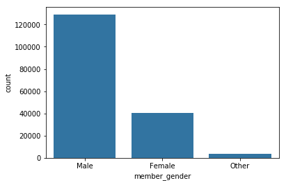

```python
#Sorting 'member_gender' in descending order
gen_order = GoBike['member_gender'].value_counts().index

# plotting a bar chart
sb.countplot(data = GoBike, x = 'member_gender', color = base_color, order = gen_order);
```

Observation: From the chart above, we have more Male riders than Female riders.

#### Question 2: What is the riders' user type category distribution?

Visualisation

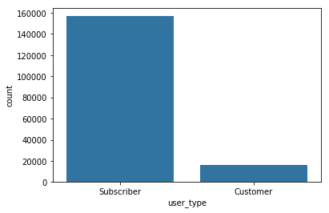

```python
#Sorting 'user_type' in descending order
user_order = GoBike['user_type'].value_counts().index

# plotting a bar chart
sb.countplot(data = GoBike, x = 'user_type', color = base_color, order = user_order);
```

Observation: This chart showed that most of the riders are suscribers

#### Question 3: What are the riders' age distribution?

Visualisation

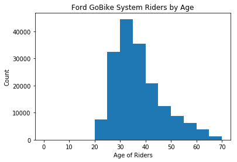

```python
bins = np.arange(0, GoBike['Age'].max()+5, 5)
plt.hist(data = GoBike, x = 'Age', bins = bins);

plt.title("Ford GoBike System Riders by Age")
plt.xlabel('Age of Riders')
plt.ylabel('Count');
```

Observation: We have more riders within the age of 30 and 40 years

#### Question 4: What is the distribution of weekly usage?

Visualisation

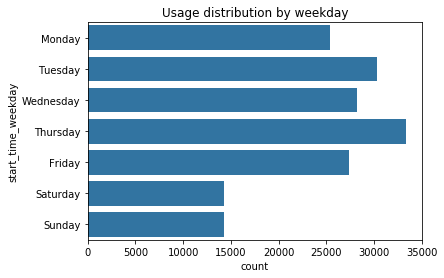

```python
#Sorting 'start_time_weekday' in descending order
Weekdays = ['Monday', 'Tuesday', 'Wednesday', 'Thursday', 'Friday', 'Saturday', 'Sunday']

# plotting a bar chart
sb.countplot(data = GoBike, y = 'start_time_weekday', color = base_color, order = Weekdays).set(title = 'Usage distribution by weekday');
```

Observation: Tuesdays and Thursdays are the days with highest usage followed by Wednessdays, Fridays and Mondays. Saturdays and Sundays record a low usage compared to the rest of the days.

#### Question 5: What is the usage distribution by hour?

Visualisation

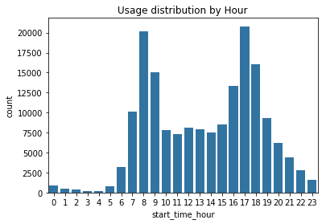

```python
# plotting a bar chart
sb.countplot(data = GoBike, x = 'start_time_hour', color = base_color).set(title = 'Usage distribution by Hour');
```

Observation: There is higher record of usage between the hours of 8am & 9am in the morning and 5pm & 6pm in the evening.

#### Question 6: What start station is the most popular?

Visualisation

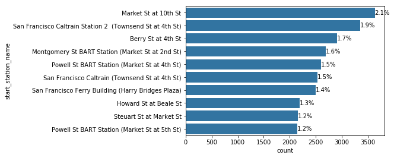

```python
n_s_station = GoBike.start_station_name.value_counts().sum()

s_station_count = GoBike.start_station_name.value_counts().head(10)

s_station_order = GoBike.start_station_name.value_counts().head(10).index

sb.countplot(data = GoBike, y ='start_station_name', color=base_color, order = s_station_order);

# Logic to print the proportion text on the bars
for i in range (s_station_count.shape[0]):

    count = s_station_count[i]
    # Convert count into a percentage, and then into string
    pct_string = '{:0.1f}%'.format(100*count/n_s_station)
    # Print the string value on the bar.

    plt.text(count+1, i, pct_string, va='center')

from matplotlib import rcParams
# Specify the figure size in inches, for both X, and Y axes
rcParams['figure.figsize'] = 9,6
```

Observation: The above chart showed the top 10 start stations with 'Market St at 10th st' being the most popular.

### Discuss the distribution(s) of your variable(s) of interest. Were there any unusual points? Did you need to perform any transformations?

> There was no unusual point and there was no need to perform any transformations.

### Of the features you investigated, were there any unusual distributions? Did you perform any operations on the data to tidy, adjust, or change the form of the data? If so, why did you do this?

> While assessing the dataset before performing any visualisation, some quality issues which include erroneous data types, missing values, and Irrelevant columns ('start_station_latitude', 'start_station_longitude','end_station_latitude', 'end_station_longitude') were identified and cleaned accordingly.

There was no unusual distribution identified.

## Bivariate Exploration

#### Question 1: What is the relationship between Hours and number of trips by user types?

Visualisation

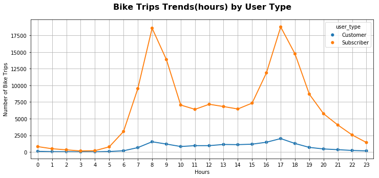

```python
plt.figure(figsize=(12, 5))

GoBike_user_week = GoBike.groupby(['start_time_hour', 'user_type']).size().reset_index()

ax = sb.pointplot(data=GoBike_user_week, x='start_time_hour', y=0, hue = 'user_type', scale=.7);

plt.title('Bike Trips Trends(hours) by User Type', y=1.05, fontsize=16, fontweight='bold')
plt.xlabel('Hours')
plt.ylabel('Number of Bike Trips');
plt.grid()
```

Observation: Subscribers made the highest trips in the morning (8am - 9am) and in the evening (5pm - 6pm). compared to customers.

#### Question 2: What is the relationship between weekdays and number of trips by user types?

Visualisation

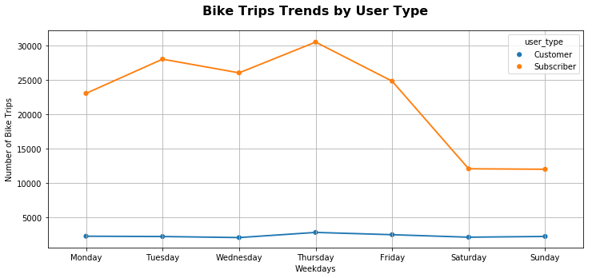

```python
plt.figure(figsize=(12, 5))

GoBike_user_week = GoBike.groupby(['start_time_weekday', 'user_type']).size().reset_index()
weekday = ['Monday', 'Tuesday', 'Wednesday', 'Thursday', 'Friday', 'Saturday', 'Sunday']

ax = sb.pointplot(data=GoBike_user_week, x='start_time_weekday', y=0, hue = 'user_type', scale=.7, order = weekday);

plt.title('Bike Trips Trends by User Type', y=1.05, fontsize=16, fontweight='bold')
plt.xlabel('Weekdays')
plt.ylabel('Number of Bike Trips');
plt.grid()
```

Observation: Subscribers makes higher number of trips with Thursdays being the highest and low usage on weekends, compared to customers who have relatively low usage.

#### Question 3: What is the relationship between gender and number of trips by the user types?

Visualisation

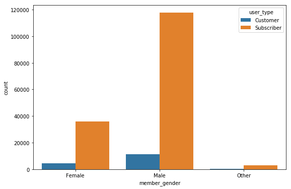

```python
sb.countplot(data = GoBike, x = 'member_gender', hue = 'user_type')
```

Observation: Most of the suscribers and customers are male.

#### Question 4: what is the relationship between the user types usage and their age?

Visualisation

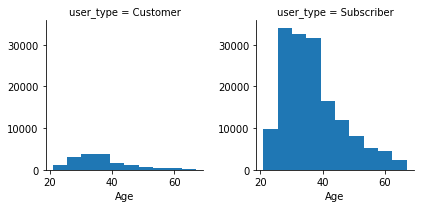

```python
# Customer vs Subscriber Usage by Age
# Plot the Seaborn's FacetGrid
g = sb.FacetGrid(data = GoBike, col = 'user_type')
g.map(plt.hist, "Age")
```

Most of the Riders with the highest usage in both user types are within the age of 30 and 40 years.

#### Question 5: What's the relationship between type of users and ride duration?

Visualisation

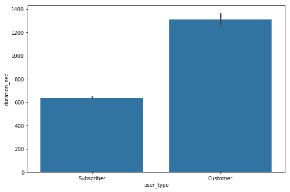

```python
# plotting bar plot
p = GoBike.user_type.value_counts().index
sb.barplot(y='duration_sec' , x='user_type' ,data=GoBike , order=p, color = base_color);
```

Customer spend longer time on trips compared to Suscribers

#### Question 6: What is the relationship betwwen trip duration and riders?

Visualisation

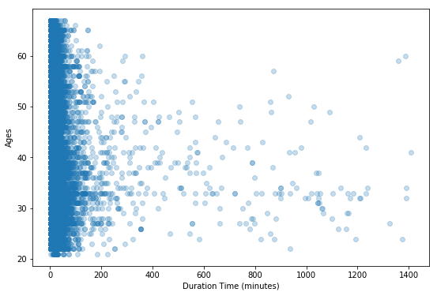

```python
# plotting relation between ages and time tripping
plt.scatter(data=GoBike, x='duration_min', y='Age', alpha=5/20);
plt.xlabel('Duration Time (minutes)')
plt.ylabel('Ages');
```

Most Riders in all age bracket spend less than 200 minutes(3hrs 20min) on trips.

### Did you observe any interesting relationships between the other features (not the main feature(s) of interest)?

> Despite the fact that suscribers use the bike sharing sytem the most, most of them take shorter rides compared to Customers who make trips on fewer occassions but take longer rides.

## Multivariate Exploration

#### Question 1: What's the relationship between rider's age of both customer & suscribers and trip duration(min)?

Visualisation

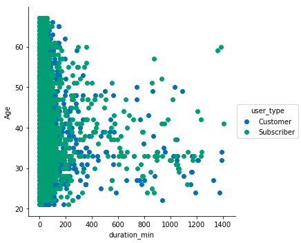

```python
g = sb.FacetGrid(data = GoBike, hue = 'user_type', size = 5,
                 palette = 'colorblind')
g.map(plt.scatter, 'duration_min', 'Age')
g.add_legend()
```

Observation: Just few of the Riders makes longer trips while most of them makes quick trips

#### Question 2: What's the relationship between rider's age of both customer & suscribers and trip duration(min) showing by gender?

Visualisation

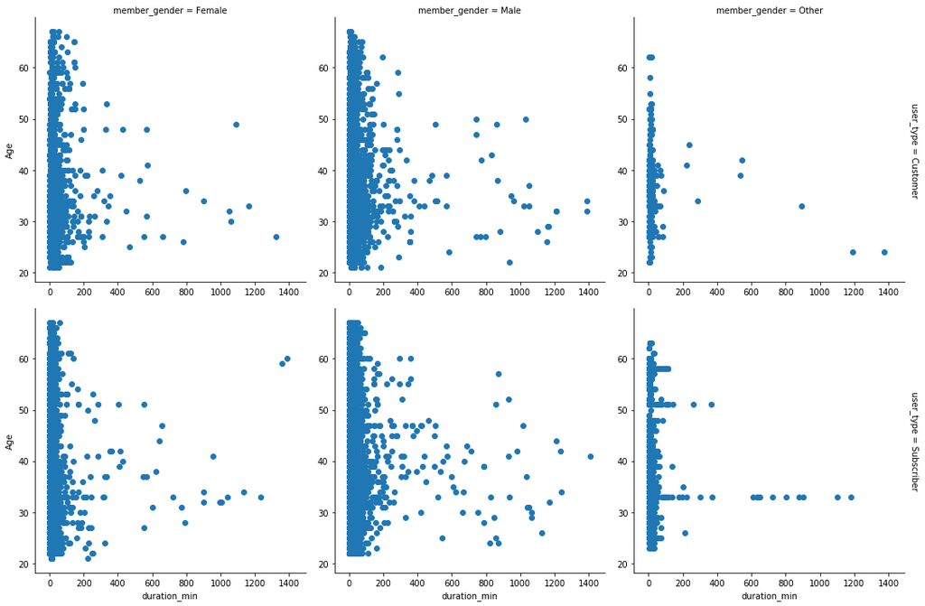

```python
g = sb.FacetGrid(data = GoBike, col = 'member_gender', row = 'user_type', size = 5,
                margin_titles = True)
g.map(plt.scatter, 'duration_min', 'Age');
```

#### Quuestion 3: What is the relationship between Riders' Trip duration and days of the week?

Visualisation

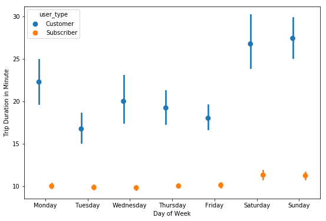

```python
weekday = ['Monday', 'Tuesday', 'Wednesday', 'Thursday', 'Friday', 'Saturday', 'Sunday']
sb.pointplot(data=GoBike, x='start_time_weekday', y='duration_min', hue='user_type', dodge=0.3, linestyles="", order = weekday);
plt.xlabel('Day of Week');
plt.ylabel('Trip Duration in Minute');
```

Observation: The above chart showed that Suscribers makes shorter trips both on week days and weekends compared to Customers who makes longer trip with the longest on weekends.

#### Question 4: What is the relationship between riders' usage hours and the weekdays?

Visualisation

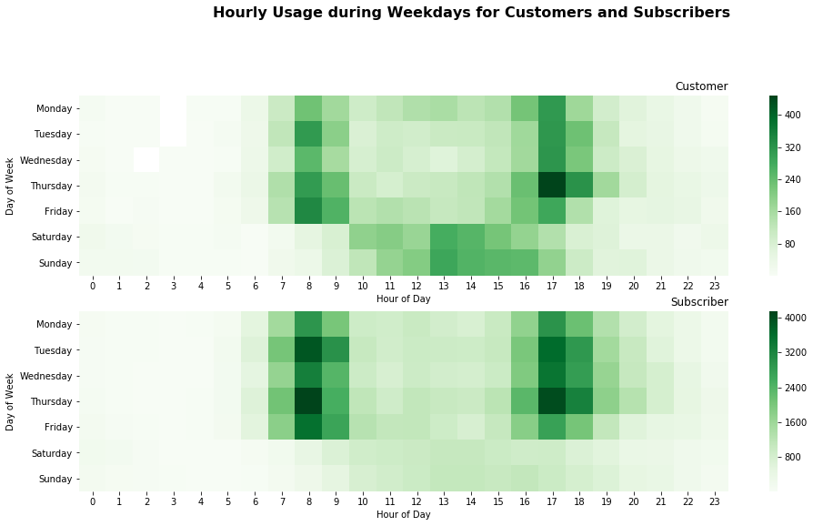

```python
weekday = ['Monday', 'Tuesday', 'Wednesday', 'Thursday', 'Friday', 'Saturday', 'Sunday']
weekday_categ = pd.api.types.CategoricalDtype(ordered=True, categories=weekday)
GoBike['start_time_weekday'] = GoBike['start_time_weekday'].astype(weekday_categ)

plt.figure(figsize = (16,8));
plt.subplot(2, 1, 1)
customers = GoBike.query('user_type == "Customer"')
cs_counts = customers.groupby(['start_time_weekday', 'start_time_hour']).size()
cs_counts = cs_counts.reset_index(name='count')
cs_counts = cs_counts.pivot(index='start_time_weekday', columns='start_time_hour', values='count')
sb.heatmap(cs_counts, cmap='Greens');
plt.title('Customer', loc='right');
plt.xlabel('Hour of Day');
plt.ylabel('Day of Week');
plt.suptitle('Hourly Usage during Weekdays for Customers and Subscribers', y=1.05, fontsize=16, fontweight='bold');



plt.subplot(2, 1, 2);
subscribers = GoBike.query('user_type == "Subscriber"')
sb_counts = subscribers.groupby(['start_time_weekday', 'start_time_hour']).size()
sb_counts = sb_counts.reset_index(name='count')
sb_counts = sb_counts.pivot(index='start_time_weekday', columns='start_time_hour', values='count')
sb.heatmap(sb_counts, cmap='Greens');
plt.title('Subscriber', loc='right');
plt.xlabel('Hour of Day');
plt.ylabel('Day of Week');
```

Observation: This further emphasize a high record of usage in the morning and evening for Riders (Customers & Suscribers) on weekdays (Mondays to Friday). Customers make trips on weekends.

### Talk about some of the relationships you observed in this part of the investigation. Were there features that strengthened each other in terms of looking at your feature(s) of interest?

> The explorations done showed that most suscribers makes short and quick trips during rushing hours (resumption time from 8am -9am and closing time 5pm - 6pm) on weekdays, Monday through Friday. This indicate that the use is primarily for work or school runs. The riders especially the customers takes longer trips on weekends, this indicate that they make use of the bike sharing system mostly for city tour and probably leisure purpose.

### Were there any interesting or surprising interactions between features?

> There are no surprising interactions, all features explored supplement each other.